# GitHub Innovation Graph: Popular Languages by Country

## About the data

We use the [GitHub Innovation Graph](https://github.com/github/innovationgraph) `languages.csv` dataset. Each row reports the number of distinct GitHub users who pushed code in a given **language**, from a given **economy** (ISO-3166-1 alpha-2 code), in a given **quarter**.

```r
library(tidyverse)
library(scales)

theme_set(theme_minimal(base_size = 11))

langs <- read_csv("languages.csv", show_col_types = FALSE)
glimpse(langs)
```

```
Rows: 161,922
Columns: 6
$ num_pushers   <dbl> 2066, 1627, 288, 108, 1734, 816, 712, 685, 377, 373, 354…
$ language      <chr> "HTML", "CSS", "Jupyter Notebook", "Vue", "JavaScript", …
$ language_type <chr> "markup", "markup", "markup", "markup", "programming", "…
$ iso2_code     <chr> "AE", "AE", "AE", "AE", "AE", "AE", "AE", "AE", "AE", "A…
$ year          <dbl> 2020, 2020, 2020, 2020, 2020, 2020, 2020, 2020, 2020, 20…
$ quarter       <dbl> 1, 1, 1, 1, 1, 1, 1, 1, 1, 1, 1, 1, 1, 1, 1, 1, 1, 1, 1,…
```

```r
langs |>
  summarise(
    rows       = n(),
    countries  = n_distinct(iso2_code),
    languages  = n_distinct(language),
    first_q    = min(paste0(year, "Q", quarter)),
    last_q     = max(paste0(year, "Q", quarter))
  )
```

| rows | countries | languages | first_q | last_q |
| --- | --- | --- | --- | --- |
| 161922 | 178 | 396 | 2020Q1 | 2025Q3 |

A small ISO2 → country-name lookup so plots are readable. We only need names for the countries that will appear in the figures.

```r
country_name <- c(
  US = "United States",   IN = "India",          CN = "China",
  DE = "Germany",         GB = "United Kingdom", BR = "Brazil",
  FR = "France",          JP = "Japan",          RU = "Russia",
  CA = "Canada",          ES = "Spain",          IT = "Italy",
  NL = "Netherlands",     KR = "South Korea",    AU = "Australia",
  PL = "Poland",          UA = "Ukraine",        ID = "Indonesia",
  TR = "Türkiye",         MX = "Mexico",         SE = "Sweden",
  CH = "Switzerland",     IL = "Israel",         AR = "Argentina",
  VN = "Vietnam",         TW = "Taiwan",         HK = "Hong Kong",
  SG = "Singapore",       BE = "Belgium",        AT = "Austria",
  IR = "Iran",            EG = "Egypt",          PK = "Pakistan",
  BD = "Bangladesh",      NG = "Nigeria",        ZA = "South Africa",
  RO = "Romania",         CZ = "Czechia",        FI = "Finland",
  NO = "Norway",          DK = "Denmark",        PT = "Portugal",
  IE = "Ireland",         GR = "Greece",         TH = "Thailand"
)

iso_to_name <- function(x) coalesce(country_name[x], x)
```

## Snapshot quarter

We use the latest available quarter as the snapshot for “popular *now*”.

```r
latest <- langs |> slice_max(year * 10 + quarter, n = 1) |>
  distinct(year, quarter)
latest
```

| year | quarter |
| --- | --- |
| 2025 | 3 |

```r
snap <- langs |> semi_join(latest, by = c("year", "quarter"))
```

## Globally most-used languages (latest quarter)

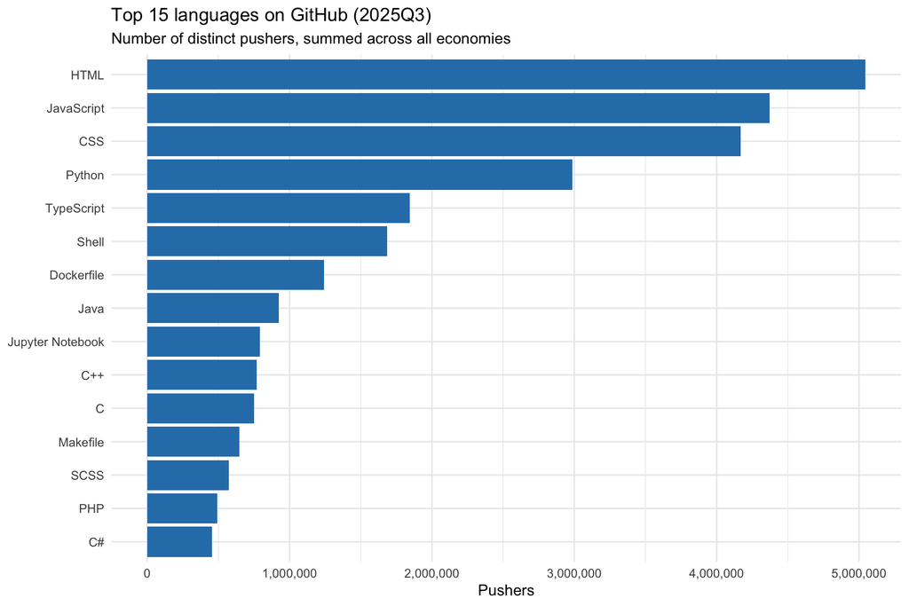

Figure 1

```r
top_global <- snap |>
  group_by(language) |>
  summarise(pushers = sum(num_pushers), .groups = "drop") |>
  slice_max(pushers, n = 15)

ggplot(top_global, aes(pushers, fct_reorder(language, pushers))) +
  geom_col(fill = "#2c7fb8") +
  scale_x_continuous(labels = label_comma()) +
  labs(
    title    = sprintf("Top 15 languages on GitHub (%dQ%d)",
                       latest$year, latest$quarter),
    subtitle = "Number of distinct pushers, summed across all economies",
    x = "Pushers", y = NULL
  )
```

## #1 language in each country

For every country with a meaningful amount of activity, we take its single most-used language in the latest quarter.

```r
country_totals <- snap |>
  group_by(iso2_code) |>
  summarise(total = sum(num_pushers), .groups = "drop")

top_per_country <- snap |>
  group_by(iso2_code, language) |>
  summarise(pushers = sum(num_pushers), .groups = "drop") |>
  group_by(iso2_code) |>
  slice_max(pushers, n = 1, with_ties = FALSE) |>
  ungroup() |>
  inner_join(country_totals, by = "iso2_code") |>
  mutate(share = pushers / total)
```

Which language is #1 in how many countries?

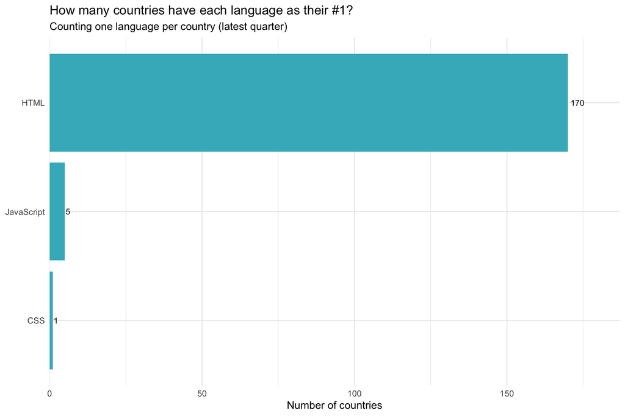

Figure 2

```r
rank1 <- top_per_country |>
  count(language, sort = TRUE)

ggplot(rank1, aes(n, fct_reorder(language, n))) +
  geom_col(fill = "#41b6c4") +
  geom_text(aes(label = n), hjust = -0.2, size = 3) +
  scale_x_continuous(expand = expansion(mult = c(0, 0.1))) +
  labs(
    title    = "How many countries have each language as their #1?",
    subtitle = "Counting one language per country (latest quarter)",
    x = "Number of countries", y = NULL
  )
```

The top-25 countries by total pushers, with their #1 language:

```r
top_per_country |>
  slice_max(total, n = 25) |>
  transmute(
    Country  = iso_to_name(iso2_code),
    `#1 language` = language,
    Pushers  = comma(pushers),
    `Share of country` = percent(share, accuracy = 0.1)
  )
```

| Country | #1 language | Pushers | Share of country |
| --- | --- | --- | --- |
| India | HTML | 1,056,421 | 18.9% |
| United States | HTML | 545,769 | 11.7% |
| EU | HTML | 530,177 | 11.8% |
| Brazil | HTML | 295,540 | 18.6% |
| Germany | HTML | 100,852 | 9.8% |
| United Kingdom | HTML | 96,632 | 11.6% |
| Indonesia | HTML | 136,522 | 17.1% |
| Japan | HTML | 99,649 | 12.7% |
| France | HTML | 83,121 | 11.9% |
| Canada | HTML | 84,406 | 12.4% |

[output cut: 15 more lines]

## Heatmap: top languages × top countries

For the 20 most-active countries we compute each language’s share of pushers *within that country*, then keep the 15 globally most-used languages.

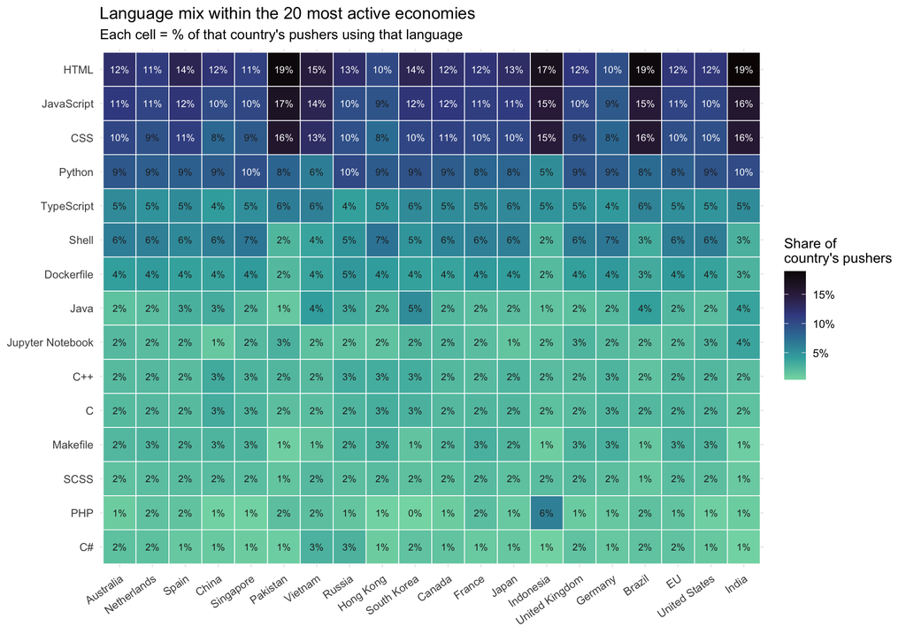

Figure 3

```r
top_countries <- country_totals |>
  slice_max(total, n = 20) |>
  pull(iso2_code)

top_langs <- top_global$language

heat <- snap |>
  filter(iso2_code %in% top_countries, language %in% top_langs) |>
  group_by(iso2_code, language) |>
  summarise(pushers = sum(num_pushers), .groups = "drop") |>
  inner_join(country_totals, by = "iso2_code") |>
  mutate(
    share        = pushers / total,
    country_name = iso_to_name(iso2_code),
    country_name = fct_reorder(country_name, total),
    language     = factor(language, levels = rev(top_langs))
  ) |>
  mutate(text_color = if_else(share > 0.5 * max(share), "white", "grey15"))

ggplot(heat, aes(country_name, language, fill = share)) +
  geom_tile(color = "white", linewidth = 0.3) +
  geom_text(aes(label = percent(share, accuracy = 1), color = text_color),
            size = 2.7) +
  scale_color_identity() +
  scale_fill_viridis_c(option = "mako", direction = -1, end = 0.85,
                       labels = label_percent(),
                       name   = "Share of\ncountry's pushers") +
  labs(
    title    = "Language mix within the 20 most active economies",
    subtitle = "Each cell = % of that country's pushers using that language",
    x = NULL, y = NULL
  ) +
  theme(axis.text.x = element_text(angle = 35, hjust = 1))
```

## Where is each language disproportionately popular?

A language’s “national share” minus its “global share” highlights places where it is *over-* or *under*-represented.

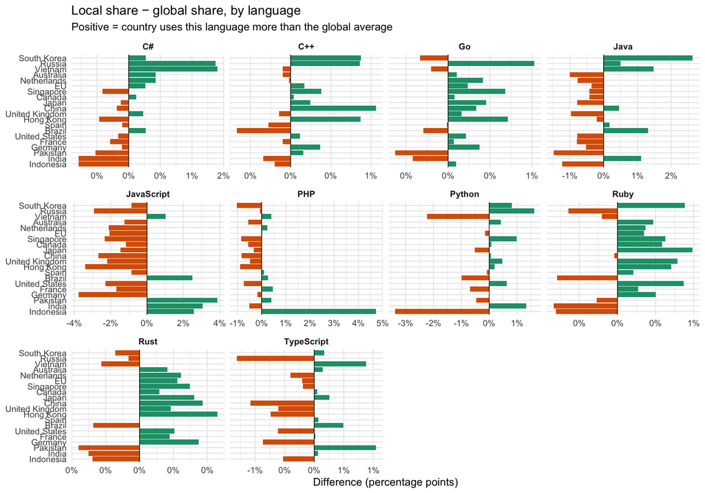

Figure 4

```r
global_share <- snap |>
  group_by(language) |>
  summarise(pushers = sum(num_pushers), .groups = "drop") |>
  mutate(global_share = pushers / sum(pushers)) |>
  select(language, global_share)

focus_langs <- c("Python", "JavaScript", "TypeScript", "Java",
                 "C++", "C#", "Go", "Rust", "PHP", "Ruby")

skew <- snap |>
  filter(iso2_code %in% top_countries, language %in% focus_langs) |>
  group_by(iso2_code, language) |>
  summarise(pushers = sum(num_pushers), .groups = "drop") |>
  inner_join(country_totals, by = "iso2_code") |>
  mutate(country_share = pushers / total) |>
  inner_join(global_share, by = "language") |>
  mutate(
    delta        = country_share - global_share,
    country_name = iso_to_name(iso2_code)
  )

ggplot(skew, aes(delta, fct_reorder(country_name, delta),
                 fill = delta > 0)) +
  geom_col() +
  geom_vline(xintercept = 0, linewidth = 0.3) +
  facet_wrap(~ language, scales = "free_x") +
  scale_x_continuous(labels = label_percent(accuracy = 1)) +
  scale_fill_manual(values = c(`TRUE` = "#1b9e77", `FALSE` = "#d95f02"),
                    guide = "none") +
  labs(
    title    = "Local share − global share, by language",
    subtitle = "Positive = country uses this language more than the global average",
    x = "Difference (percentage points)", y = NULL
  ) +
  theme(strip.text = element_text(face = "bold"))
```

## Trend over time

How have the headline languages moved globally since 2020?

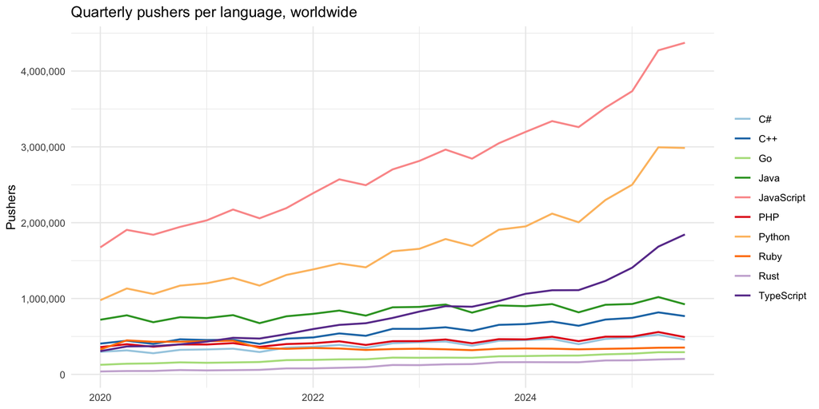

Figure 5

```r
trend <- langs |>
  filter(language %in% focus_langs) |>
  group_by(year, quarter, language) |>
  summarise(pushers = sum(num_pushers), .groups = "drop") |>
  mutate(date = yq(paste0(year, " Q", quarter)))

ggplot(trend, aes(date, pushers, color = language)) +
  geom_line(linewidth = 0.8) +
  scale_y_continuous(labels = label_comma()) +
  scale_color_brewer(palette = "Paired") +
  labs(
    title    = "Quarterly pushers per language, worldwide",
    x = NULL, y = "Pushers", color = NULL
  )
```